- Show All Code
- Hide All Code
- View Source

# AIDIS Round 77: Household Wealth Classification Across Indian States under a Heterogenous Agent framework

# Setup

## Packages

```r
#install.packages(c("haven","dplyr","tidyr","purrr","ggplot2", "sf","rnaturalearth","rmapshaper","patchwork"))

library(haven)
library(dplyr)
library(tidyr)
library(purrr)
library(ggplot2)
library(sf)
library(rnaturalearth)
library(rmapshaper)
library(patchwork)
```

## Data path

```r
data_dir <- "C:/Users/HP/Downloads/Round77sch18pt2Data"
```

## Helper functions

```r
make_key <- function(df) {
  names(df) <- tolower(names(df))
  df |> mutate(hh_key = as.character(hhid))
}

safe_sum <- function(path, var) {
  if (!file.exists(path)) return(tibble(hh_key = character()))
  read_dta(path) |>
    make_key() |>
    group_by(hh_key) |>
    summarise(val = sum(as.numeric(.data[[var]]), na.rm = TRUE), .groups = "drop")
}
```

# Introduction

This project looks at how Indian households manage their money and how many of them are basically living paycheck to paycheck versus having real savings to fall back on. The data comes from the **All India Debt and Investment Survey (AIDIS), Round 77**, run by India’s National Statistical Office in 2019. Economists call the paycheck-to-paycheck group “hand-to-mouth” households, and they matter a lot because they’re the ones who actually spend extra income right away, which is a big deal for how policy (like tax cuts or rate changes) flows through the economy. I try two ways of sorting households into these groups i) a simple one based on liquid wealth, and ii) the Kaplan–Violante method that also factors in illiquid assets like land. I then map what the picture looks like across Indian states.

# Data processing

Here I’m pulling in the basic household info from Blocks 1 & 2 (state code and survey multiplier weights), plus financial assets from Block 11a (bank deposits, bonds, provident funds) and shares from Block 11b (company shares, mutual funds). Together these make up a household’s liquid wealth: assets they could convert to cash quickly if needed.

## Core household identifiers

```r
id_df <- read_dta(file.path(data_dir, "Visit1  Level - 01 (Blocks 1 and 2).dta")) |>
  make_key() |>
  transmute(
    hh_key,
    state = as.integer(state),
    wt    = as.numeric(mlt)
  )
```

## Financial and share assets

```r
fin <- safe_sum(file.path(data_dir, "Visit1  Level - 12 (Block 11a).dta"), "b11aq6")
shr <- safe_sum(file.path(data_dir, "Visit1  Level - 13 (Block 11b).dta"), "b11bq6")
```

## Merge into master

```r
master <- id_df |>
  left_join(fin, by = "hh_key") |>
  left_join(shr, by = "hh_key") |>
  mutate(across(everything(), ~ replace_na(.x, 0)))
```

# Liquid-only classification

The INR 12,000 threshold follows the **Kaplan–Violante (2014)** convention, where a household is “hand-to-mouth” if liquid wealth falls below roughly half of one pay period’s income. Applied to India’s AIDIS 77 (2019) context, this corresponds to about two weeks of median household earnings, giving a cutoff near INR 12,000. Households below this line cannot smooth even a brief income shock, which is the economic intuition behind the HtM label. Alternative specifications could include different levels for rural-urban split, or a more conservative split of INR 8,000.

```r
master <- master |>
  mutate(
    net_liquid = val.x + val.y,
    threshold  = 12000,
    agent_type = case_when(
      net_liquid <= threshold     ~ "Poor HtM",
      net_liquid <= 2 * threshold ~ "Wealthy HtM",
      TRUE                        ~ "Ricardian"
    )
  )
```

## State-level shares

```r
state_results <- master |>
  group_by(state, agent_type) |>
  summarise(w = sum(wt), .groups = "drop") |>
  group_by(state) |>
  mutate(share_pct = w / sum(w) * 100) |>
  ungroup()
```

```r
state_lookup <- tibble::tribble(
  ~state, ~state_name,
   1, "Jammu & Kashmir",        2, "Himachal Pradesh",
   3, "Punjab",                 4, "Chandigarh",
   5, "Uttarakhand",            6, "Haryana",
   7, "Delhi",                  8, "Rajasthan",
   9, "Uttar Pradesh",         10, "Bihar",
  11, "Sikkim",                12, "Arunachal Pradesh",
  13, "Nagaland",              14, "Manipur",
  15, "Mizoram",               16, "Tripura",
  17, "Meghalaya",             18, "Assam",
  19, "West Bengal",           20, "Jharkhand",
  21, "Odisha",                22, "Chhattisgarh",
  23, "Madhya Pradesh",        24, "Gujarat",
  25, "Daman & Diu",           26, "Dadra & Nagar Haveli",
  27, "Maharashtra",           28, "Andhra Pradesh (Old)",
  29, "Karnataka",             30, "Goa",
  31, "Lakshadweep",           32, "Kerala",
  33, "Tamil Nadu",            34, "Puducherry",
  35, "Andaman & Nicobar",     36, "Telangana",
  37, "Andhra Pradesh"
)

state_final <- state_results |>
  left_join(state_lookup, by = "state") |>
  mutate(
    state_name = case_when(
      state_name == "Jammu & Kashmir"    ~ "Jammu and Kashmir",
      state_name == "Andaman & Nicobar"  ~ "Andaman and Nicobar",
      state_name %in% c("Dadra & Nagar Haveli", "Daman & Diu") ~
        "Dadra and Nagar Haveli and Daman and Diu",
      state_name == "Andhra Pradesh (Old)" ~ "Andhra Pradesh",
      TRUE ~ state_name
    )
  ) |>
  group_by(state_name, agent_type) |>
  summarise(share_pct = mean(share_pct), .groups = "drop")
```

## Map setup and plot functions

```r
UTs <- c(
  "Andaman and Nicobar",
  "Chandigarh",
  "Dadra and Nagar Haveli and Daman and Diu",
  "Lakshadweep",
  "Puducherry",
  "Delhi"
)

india_map <- ne_states(country = "India", returnclass = "sf") |>
  select(name, geometry) |>
  rmapshaper::ms_simplify(keep = 0.05)
```

```r
plot_map <- function(d, title) {
  ggplot() +
    # UTs shaded dark grey
    geom_sf(
      data  = d |> filter(name %in% UTs),
      fill  = "grey20",
      color = "white",
      size  = 0.2
    ) +
    # States coloured by share
    geom_sf(
      data = d |> filter(!name %in% UTs),
      aes(fill = share_pct),
      color = "white",
      size  = 0.2
    ) +
    scale_fill_gradient(
      low      = "#deebf7",
      high     = "#08519c",
      limits   = c(0, 100),
      na.value = "grey90"
    ) +
    labs(title = title, fill = "% households") +
    theme_minimal() +
    theme(
      plot.title      = element_text(face = "bold"),
      legend.position = "bottom"
    )
}
```

## Share of states of Poor hand to mouth (HtM), Wealth HtM and Ricardian households by state

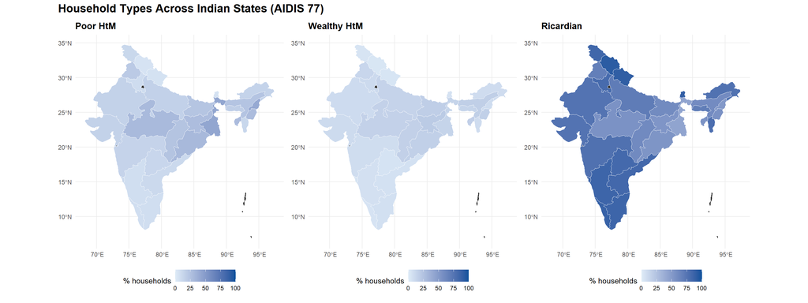

Figure 1: Liquid-only classification: shares of Poor HtM, Wealthy HtM, and Ricardian households by state.

```r
map_data <- india_map |>
  left_join(state_final, by = c("name" = "state_name"))

mp <- map_data |> filter(agent_type == "Poor HtM")
mw <- map_data |> filter(agent_type == "Wealthy HtM")
mr <- map_data |> filter(agent_type == "Ricardian")

p1 <- plot_map(mp, "Poor HtM")
p2 <- plot_map(mw, "Wealthy HtM")
p3 <- plot_map(mr, "Ricardian")

final_plot <- (p1 | p2 | p3) +
  plot_annotation(
    title = "Household Types Across Indian States (AIDIS 77)",
    theme = theme(plot.title = element_text(face = "bold", size = 16))
  )

final_plot

ggsave("kv_final_3panel_map.png", final_plot,
       width = 16, height = 6, dpi = 300)
```

# Kaplan–Violante (KV) classification

The KV approach adds an **illiquid wealth** dimension (land) on top of liquid wealth, producing four household types It refines the hand-to-mouth classification by recognising that many households hold substantial **illiquid wealth** (assets that are valuable but costly or slow to convert into cash). These households look poor on a bank statement but aren’t truly wealth-constrained, so they behave differently from the genuinely poor. In the Indian context, land is the dominant illiquid asset. This chunk pulls three land-value variables from Block 9 of AIDIS using `b9q2`, `b9q3`, and `b9q4`, covering different categories of land owned and then sums them per household, and produces `ill_land`, the total illiquid wealth used in the KV classification (still kept at INR 12,000).

## Build illiquid (land) wealth

```r
land  <- safe_sum(file.path(data_dir, "Visit1  Level - 10 (Block 9).dta"), "b9q2") |>
  rename(land1 = val)
land2 <- safe_sum(file.path(data_dir, "Visit1  Level - 10 (Block 9).dta"), "b9q3") |>
  rename(land2 = val)
land3 <- safe_sum(file.path(data_dir, "Visit1  Level - 10 (Block 9).dta"), "b9q4") |>
  rename(land3 = val)

ill_land <- land |>
  full_join(land2, by = "hh_key") |>
  full_join(land3, by = "hh_key") |>
  mutate(
    land1    = replace_na(land1, 0),
    land2    = replace_na(land2, 0),
    land3    = replace_na(land3, 0),
    ill_land = land1 + land2 + land3
  ) |>
  select(hh_key, ill_land)
```

## Build `master2` with liquid + illiquid

```r
master2 <- id_df |>
  left_join(fin, by = "hh_key") |>
  left_join(shr, by = "hh_key") |>
  mutate(
    fin_val    = replace_na(val.x, 0),
    shr_val    = replace_na(val.y, 0),
    net_liquid = fin_val + shr_val
  ) |>
  left_join(ill_land, by = "hh_key") |>
  mutate(
    ill_land     = replace_na(ill_land, 0),
    illiquid     = ill_land,
    total_wealth = net_liquid + illiquid
  )
```

## KV classification and state shares

```r
master2 <- master2 |>
  mutate(
    threshold = 12000,
    kv_type = case_when(
      net_liquid <= threshold & illiquid == 0 ~ "Poor HtM",
      net_liquid <= threshold & illiquid  > 0 ~ "Illiquid-rich HtM",
      net_liquid  > threshold & illiquid == 0 ~ "Liquid-rich only",
      net_liquid  > threshold & illiquid  > 0 ~ "Ricardian (dual asset)"
    )
  )
```

```r
state_results_kv <- master2 |>
  group_by(state, kv_type) |>
  summarise(w = sum(wt), .groups = "drop") |>
  group_by(state) |>
  mutate(share_pct = w / sum(w) * 100) |>
  ungroup()

state_final_kv <- state_results_kv |>
  left_join(state_lookup, by = "state") |>
  mutate(
    state_name = case_when(
      state_name == "Jammu & Kashmir"    ~ "Jammu and Kashmir",
      state_name == "Andaman & Nicobar"  ~ "Andaman and Nicobar",
      state_name %in% c("Dadra & Nagar Haveli", "Daman & Diu") ~
        "Dadra and Nagar Haveli and Daman and Diu",
      state_name == "Andhra Pradesh (Old)" ~ "Andhra Pradesh",
      TRUE ~ state_name
    )
  ) |>
  group_by(state_name, kv_type) |>
  summarise(share_pct = mean(share_pct), .groups = "drop")
```

## 4-panel KV map

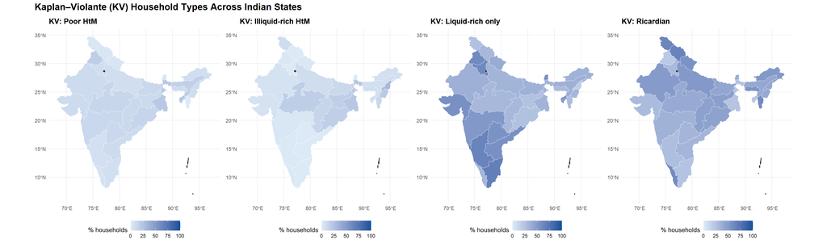

Figure 2: Kaplan–Violante classification: shares of Poor HtM, Illiquid-rich HtM, Liquid-rich only, and Ricardian households by state.

```r
map_data_kv <- india_map |>
  left_join(state_final_kv, by = c("name" = "state_name"))

mp_kv <- map_data_kv |> filter(kv_type == "Poor HtM")
mw_kv <- map_data_kv |> filter(kv_type == "Illiquid-rich HtM")
ml_kv <- map_data_kv |> filter(kv_type == "Liquid-rich only")
mr_kv <- map_data_kv |> filter(kv_type == "Ricardian (dual asset)")

p1 <- plot_map(mp_kv, "KV: Poor HtM")
p2 <- plot_map(mw_kv, "KV: Illiquid-rich HtM")
p3 <- plot_map(ml_kv, "KV: Liquid-rich only")
p4 <- plot_map(mr_kv, "KV: Ricardian")

final_plot_kv <- (p1 | p2 | p3 | p4) +
  plot_annotation(
    title = "Kaplan–Violante (KV) Household Types Across Indian States",
    theme = theme(plot.title = element_text(face = "bold", size = 16))
  )

final_plot_kv

ggsave("kv_final_4panel_map.png", final_plot_kv,
       width = 20, height = 6, dpi = 300)
```

This actually matters a lot for New Keynesian HANK-style thinking (Kaplan, Moll and Violante, 2018). In the textbook NK setup, monetary policy works by nudging the representative household to spend more or less today versus tomorrow. But if a big chunk of your population is HtM, interest rates don’t really do much for them then what drives their spending is just how much cash lands in their hand this month. The Illiquid-rich HtM group is the interesting one: on paper they look wealthy, but their MPC is high because all that wealth is stuck in land. For India, this suggests rate cuts probably don’t transmit all that well, while things like direct cash transfers or income support should punch well above their weight.

# Transition matrix: liquid → KV

How do households re-classify when we move from the liquid-only method to the KV method?

```r
transition <- master |>
  select(hh_key, state, agent_type) |>
  left_join(master2 |> select(hh_key, kv_type), by = "hh_key") |>
  group_by(agent_type, kv_type) |>
  summarise(n = n(), .groups = "drop") |>
  group_by(agent_type) |>
  mutate(share = n / sum(n) * 100) |>
  ungroup()

transition
```

```
# A tibble: 6 × 4
  agent_type  kv_type                    n share
  <chr>       <chr>                  <int> <dbl>
1 Poor HtM    Illiquid-rich HtM       8490  44.6
2 Poor HtM    Poor HtM               10546  55.4
3 Ricardian   Liquid-rich only       47212  55.3
4 Ricardian   Ricardian (dual asset) 38212  44.7
5 Wealthy HtM Liquid-rich only        6008  50.1
6 Wealthy HtM Ricardian (dual asset)  5993  49.9
```

# State-by-state comparison table

Side-by-side shares under both classifications.

```r
# Liquid-only shares
liquid_state <- master |>
  group_by(state, agent_type) |>
  summarise(w = sum(wt), .groups = "drop") |>
  group_by(state) |>
  mutate(share_liquid = w / sum(w) * 100) |>
  ungroup() |>
  select(state, agent_type, share_liquid)

# KV shares
kv_state <- master2 |>
  group_by(state, kv_type) |>
  summarise(w = sum(wt), .groups = "drop") |>
  group_by(state) |>
  mutate(share_kv = w / sum(w) * 100) |>
  ungroup() |>
  select(state, kv_type, share_kv)

# Reshape wide
liquid_wide <- liquid_state |>
  pivot_wider(names_from = agent_type, values_from = share_liquid, values_fill = 0)

kv_wide <- kv_state |>
  pivot_wider(names_from = kv_type, values_from = share_kv, values_fill = 0)

# Merge and attach state names
comparison_table <- liquid_wide |>
  left_join(kv_wide, by = "state") |>
  left_join(state_lookup, by = "state") |>
  select(state_name, everything(), -state)

comparison_table
```

```
# A tibble: 36 × 8
   state_name       `Poor HtM.x` Ricardian `Wealthy HtM` `Illiquid-rich HtM`
   <chr>                   <dbl>     <dbl>         <dbl>               <dbl>
 1 Jammu & Kashmir         11.6       84.3         4.09                8.73
 2 Himachal Pradesh         4.47      92.3         3.24                1.26
 3 Punjab                  19.6       68.0        12.4                 2.20
 4 Chandigarh              11.3       87.9         0.831               0
 5 Uttarakhand              5.63      90.7         3.65                2.00
 6 Haryana                  8.75      81.1        10.1                 0.636
 7 Delhi                   27.0       64.2         8.76                0.459
 8 Rajasthan               15.0       75.7         9.28                5.60
 9 Uttar Pradesh           15.8       69.9        14.3                 8.30
10 Bihar                   22.8       59.9        17.3                11.5
# ℹ 26 more rows
# ℹ 3 more variables: `Liquid-rich only` <dbl>, `Poor HtM.y` <dbl>,
#   `Ricardian (dual asset)` <dbl>
```

The transition matrix is where the two methods really show their differences. Look at the Ricardian row under the liquid-only method: about 47,000 of those households actually turn out to be Liquid-rich only under KV meaning they’ve got cash, sure, but no land. Only around 38,000 stay “true” Ricardian with both liquid *and* illiquid wealth. Even more telling, about 8,500 Poor HtM households flip to Illiquid-rich HtM once land is counted; they looked totally broke on a bank balance, but they actually own land. That’s the whole point of KV: the simple method was hiding a lot of wealth.